# Data Exploration

Lizbeth G Amador

2025-02-10

This script produces some figures to view the spatial-temporal extent of the data. Focal native/non-native species pairs are the following: **Exotic** – **Native**  
*Rubus laciniatus* – *Rubus spectabilis*  
*Hymenocallis littoralis* – *Hymenocallis occidentalis*  
*Ilex aquifolium* – *Ilex decidua*  
*Juglans regia* – *Juglans nigra*  
*Acer palmatum* – *Acer rubrum*

# Libraries

```r
# Load necessary libraries
#if statement to automatically install libraries if absent in r library
#tidyverse - mainly for data wrangling & plotting/mapping
if (!requireNamespace("tidyverse", quietly = TRUE)) {
  install.packages("tidyverse")
}
library(tidyverse)
#sf - spatial package for mapping
if (!requireNamespace("sf", quietly = TRUE)) {
  install.packages("sf")
}
require(sf)
```

# Import data

See `Data_Harmonizatin.R` to view harmonization of unprocessed iDibBio data with NEON, USA-NPN, and other herbarium.

```r
#TEMP
phe = read.csv(file.path(L2, #object storing folder directory - can remove fil.path(L2 if not needed
                         "FocalSpp_OpenFlowers_NeonNpnHerb_iDigBiounprocessed.csv"), header = TRUE)
```

```r
#peek into the data - uncomment lines of interest
#unique data name (akak sources)
unique(phe$data_name)
```

```
## [1] "USA-NPN"   "NEON"      "Herbarium" "iDigBio"
```

```r
#unique species observations
sort(unique(phe$species))
```

```
##  [1] "Acer palmatum"             "Acer rubrum"
##  [3] "Acer saccharum"            "Hymenocallis littoralis"
##  [5] "Hymenocallis occidentalis" "Ilex aquifolium"
##  [7] "Ilex decidua"              "Juglans nigra"
##  [9] "Juglans regia"             "Rubus laciniatus"
## [11] "Rubus spectabilis"
```

```r
#unique annual observations
# unique(phe.all$year_rect)
#unique phenophase status - 1=active, 0=inactive, -1=NA
unique(phe$phenophase_status)
```

```
## [1]  1  0 -1
```

let’s remove the absent status for a conservative estimation of sample sizes per species and time period.

```r
phe.n0 = phe %>%
  filter(phenophase_status!=0)

unique(phe.n0$phenophase_status)
```

```
## [1]  1 -1
```

```r
#all species & years
phe.n0 %>%
  filter(year_rect>=1910) %>%
  count(species)
```

```
##                      species    n
## 1              Acer palmatum  659
## 2                Acer rubrum 9451
## 3             Acer saccharum  240
## 4    Hymenocallis littoralis   25
## 5  Hymenocallis occidentalis  240
## 6            Ilex aquifolium  330
## 7               Ilex decidua 3000
## 8              Juglans nigra 3655
## 9              Juglans regia  261
## 10          Rubus laciniatus  770
## 11         Rubus spectabilis 1150
```

```r
#historical
phe.n0 %>%
  filter(year_rect>=1910, year_rect<=1950) %>%
  count(species)
```

```
##                      species    n
## 1              Acer palmatum   93
## 2                Acer rubrum 1722
## 3             Acer saccharum    8
## 4    Hymenocallis littoralis    8
## 5  Hymenocallis occidentalis   35
## 6            Ilex aquifolium   30
## 7               Ilex decidua  430
## 8              Juglans nigra  611
## 9              Juglans regia   29
## 10          Rubus laciniatus  272
## 11         Rubus spectabilis  342
```

```r
#current
phe.n0 %>%
  filter(year_rect>=1985) %>%
  count(species)
```

```
##                      species    n
## 1              Acer palmatum  315
## 2                Acer rubrum 3387
## 3             Acer saccharum  216
## 4    Hymenocallis littoralis   10
## 5  Hymenocallis occidentalis  104
## 6            Ilex aquifolium  216
## 7               Ilex decidua 1249
## 8              Juglans nigra 1389
## 9              Juglans regia  139
## 10          Rubus laciniatus  234
## 11         Rubus spectabilis  388
```

```r
#historical
phe.n0 %>%
  filter(year_rect>=1910, year_rect<=1950) %>%
  count(species, data_name)
```

```
##                      species data_name    n
## 1              Acer palmatum Herbarium    1
## 2              Acer palmatum   iDigBio   92
## 3                Acer rubrum Herbarium   19
## 4                Acer rubrum   iDigBio 1703
## 5             Acer saccharum Herbarium    8
## 6    Hymenocallis littoralis   iDigBio    8
## 7  Hymenocallis occidentalis Herbarium    3
## 8  Hymenocallis occidentalis   iDigBio   32
## 9            Ilex aquifolium   iDigBio   30
## 10              Ilex decidua   iDigBio  430
## 11             Juglans nigra Herbarium    9
## 12             Juglans nigra   iDigBio  602
## 13             Juglans regia Herbarium    2
## 14             Juglans regia   iDigBio   27
## 15          Rubus laciniatus Herbarium   29
## 16          Rubus laciniatus   iDigBio  243
## 17         Rubus spectabilis Herbarium   65
## 18         Rubus spectabilis   iDigBio  277
```

```r
#current
phe.n0 %>%
  filter(year_rect>=1985) %>%
  count(species, data_name)
```

```
##                      species data_name    n
## 1              Acer palmatum Herbarium    2
## 2              Acer palmatum   iDigBio  313
## 3                Acer rubrum Herbarium   64
## 4                Acer rubrum      NEON  219
## 5                Acer rubrum   USA-NPN  537
## 6                Acer rubrum   iDigBio 2567
## 7             Acer saccharum Herbarium   28
## 8             Acer saccharum      NEON   39
## 9             Acer saccharum   USA-NPN  149
## 10   Hymenocallis littoralis   iDigBio   10
## 11 Hymenocallis occidentalis Herbarium   10
## 12 Hymenocallis occidentalis      NEON    1
## 13 Hymenocallis occidentalis   USA-NPN    1
## 14 Hymenocallis occidentalis   iDigBio   92
```

[output cut: 21 more lines]

# Figures

## Histograms

### Non-native & Native Pairs

Now, let’s see side-by-side samples sizes for each species pair. For the sake of brevity, we provided one example but the same code chunk ca nbe applied to each species pair. Remember to adjust the species filter and the file name!

#### *Acer spp*

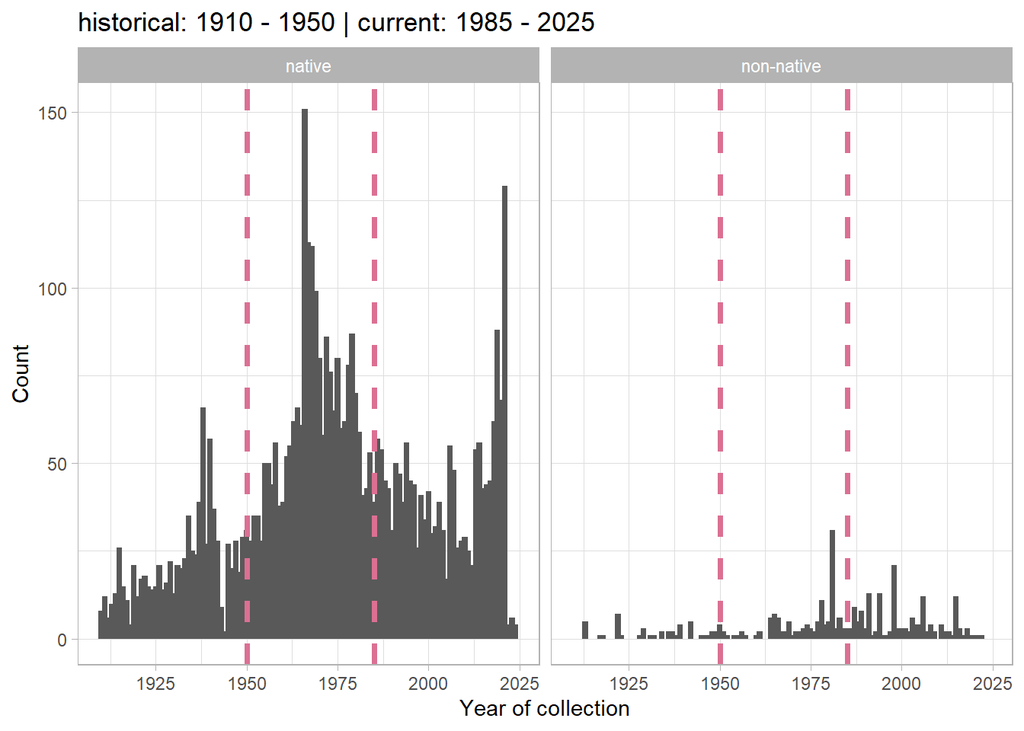

```r
phe.n0 %>%
  #remove any inactive phenophase status (i.e. 0s) - want to be conservative and only view sample sizes for active flowering status
  #Also, only keep observations since the 1910s
  #Filter for species pairs
  filter(year_rect>=1910,
         species == c("Acer palmatum", "Acer rubrum")) %>%
  #start plotting
  ggplot(aes(x= year_rect)) +
    #split plot by native status
    facet_wrap(~native_status) +
    #adjust the bar width
    geom_bar(width = 1.5) +
    #rename x/y axes
    labs(x = "Year of collection", y = "Count") +
    #plot title
    ggtitle("historical: 1910 - 1950 | current: 1985 - 2025") +
    #add vertical lines - represent years of interest
    geom_vline(xintercept = c(1950, 1985), linetype="dashed",
                color = "palevioletred", size=1.25) +
    theme_light()
```

```r
#########
# # Save the plot in the specified directory
#   ggsave("plot_Acer_pairs_Annualhist.png", last_plot(),
#          width = 7, units = "in", dpi = 600) #dpi the resolution
```

### Data source contributions

Now, let’s see how much each `data_source` contributes to the species sample size. Remember to uncomment the exporting code at the end if you’d like to save the plots.

```r
#Function to automate plotting
#inputs:
# soi: character; species of interest
#------------------------------

stakd.hist = function(soi){ #START of function
  phe.n0 %>%
    #remove any inactive phenophase status (i.e. 0s) - want to be conservative and only view sample sizes for active flowering status
    #Also, only keep observations since the 1910s
    filter(year_rect>=1910, species ==  soi) %>%
    ggplot(aes(x= year_rect, fill = data_name)) +
      geom_bar(width = 3.5) +
      #Manually assign colors to unique data_name values
      scale_fill_manual(values=c("Herbarium" = "goldenrod2",
                                 "NEON"= "turquoise4",
                                 "USA-NPN" = "grey",
                                 "iDigBio" = "grey46")) +
      #rename x/y axes
      labs(x = "Year of collection", y = "Count", fill = "Data source") +
      #plot title
      ggtitle(soi) +
      #opacity of the colors
      scale_alpha_manual(values=c(0.7,0.7,0.7)) +
      #vertical lines - represents time periods
      geom_vline(xintercept = c(1950, 1985), linetype="dashed",
                  color = "palevioletred", size=1.5)


  #########
  #Export plots - ucomment when needed

  # # Save the plot in the specified directory
    # ggsave(paste0("plot_",
    #               gsub(" ", "_", soi), #grep-like function to include the specific species name & adding a "_" in any spaces
    #               "_Annualhist_alldata",
    #               ".png"), last_plot(), #png file type
    #        width = 7, units = "in", dpi = 600) #dpi the resolution

  } #END of function
```

#### *Acer rubrum*

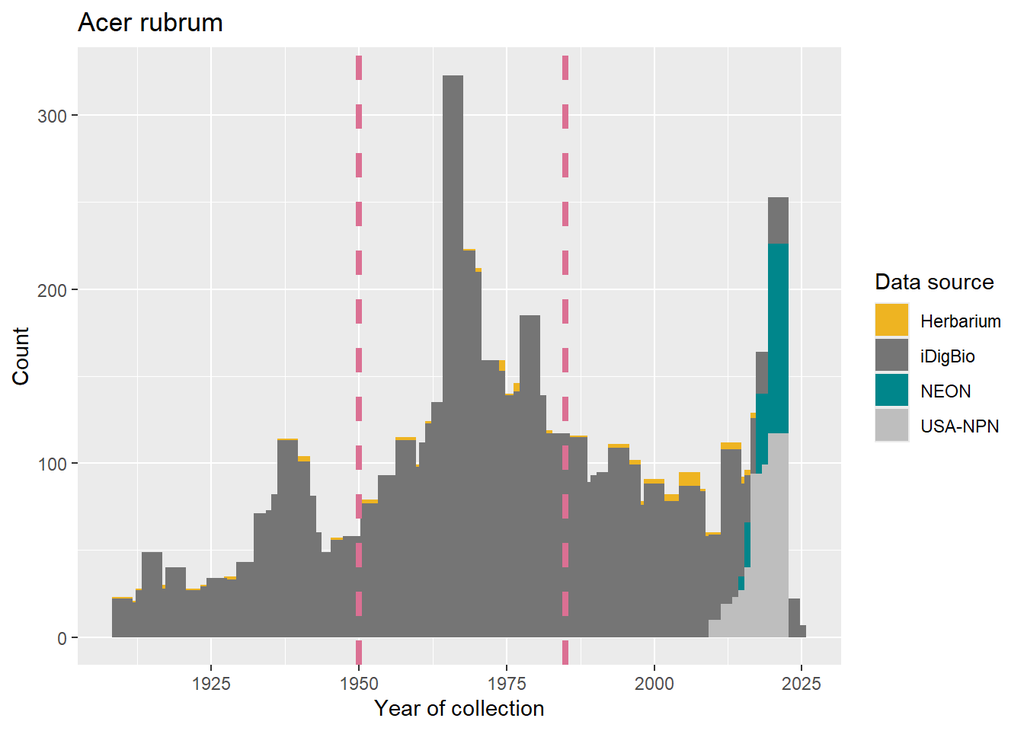

```r
stakd.hist("Acer rubrum")
```

#### *Acer palmatum*

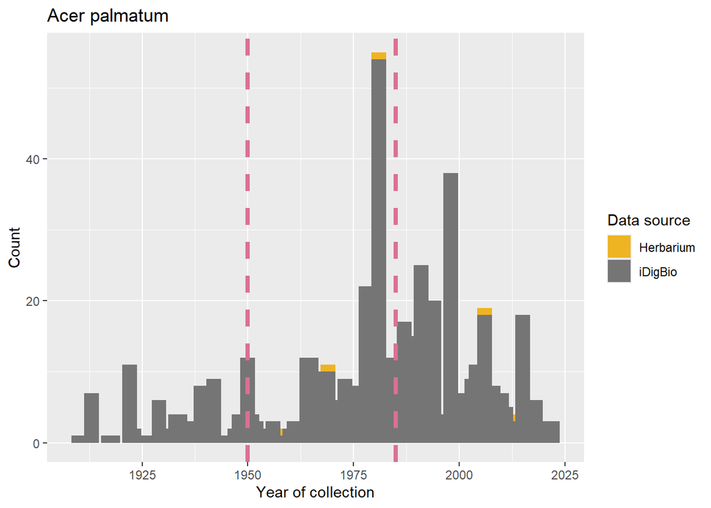

```r
stakd.hist("Acer palmatum")
```

#### *Hymenocallis occidentalis*

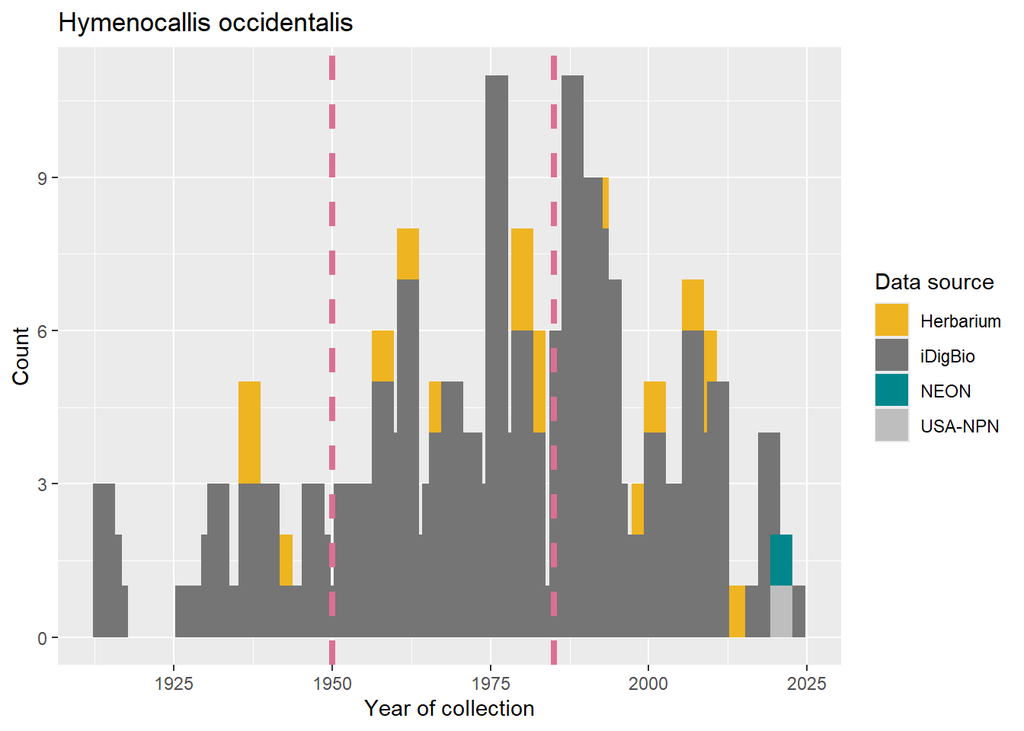

```r
stakd.hist("Hymenocallis occidentalis")
```

#### *Hymenocallis littoralis*

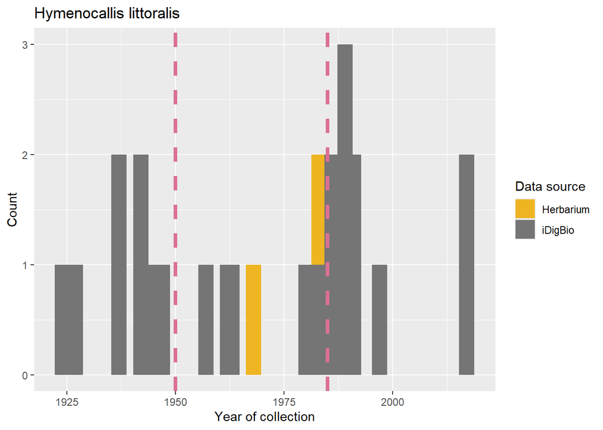

```r
stakd.hist("Hymenocallis littoralis")
```

#### *Ilex decidua*

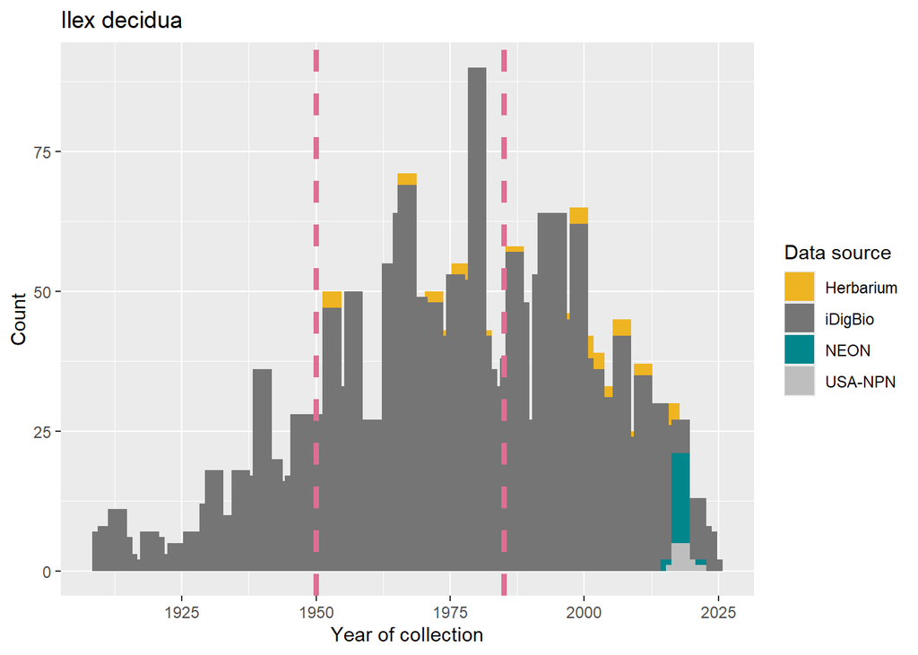

```r
stakd.hist("Ilex decidua")
```

#### *Ilex aquifolium*

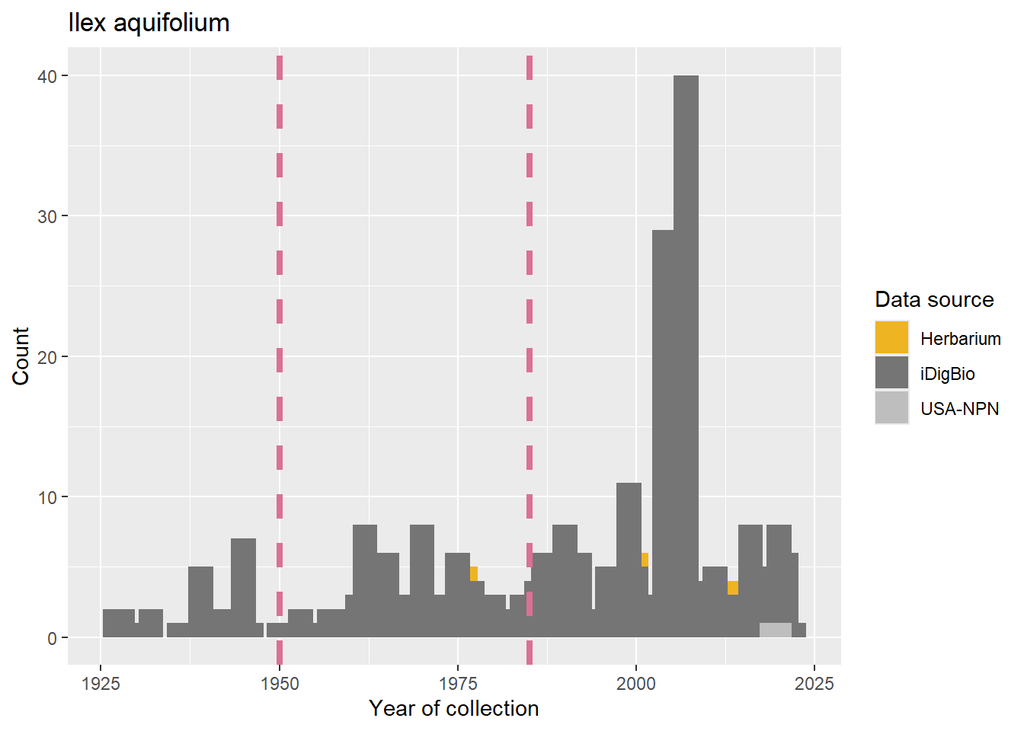

```r
stakd.hist("Ilex aquifolium")
```

#### *Juglans nigra*

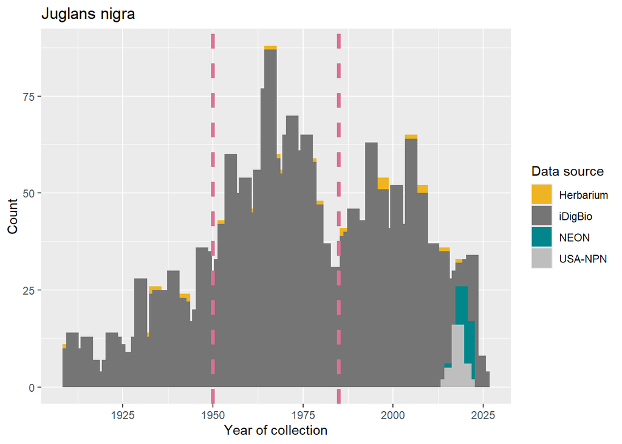

```r
stakd.hist("Juglans nigra")
```

#### *Juglans regia*

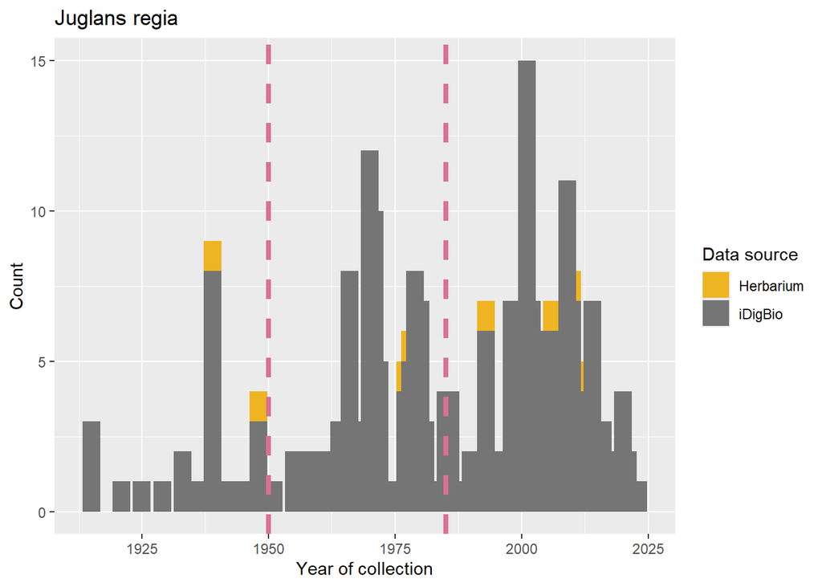

```r
stakd.hist("Juglans regia")
```

#### *Rubus spectabilis*

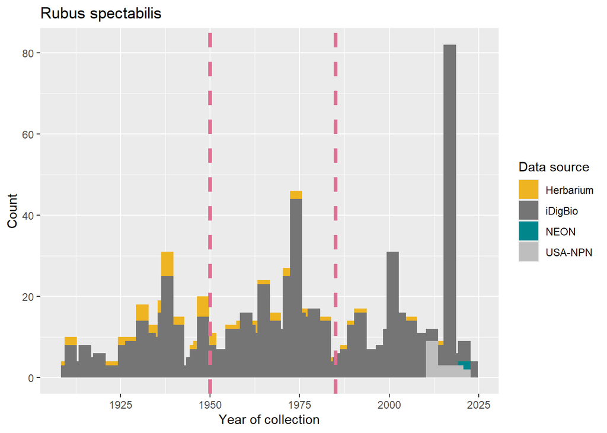

```r
stakd.hist("Rubus spectabilis")
```

#### *Rubus laciniatus*

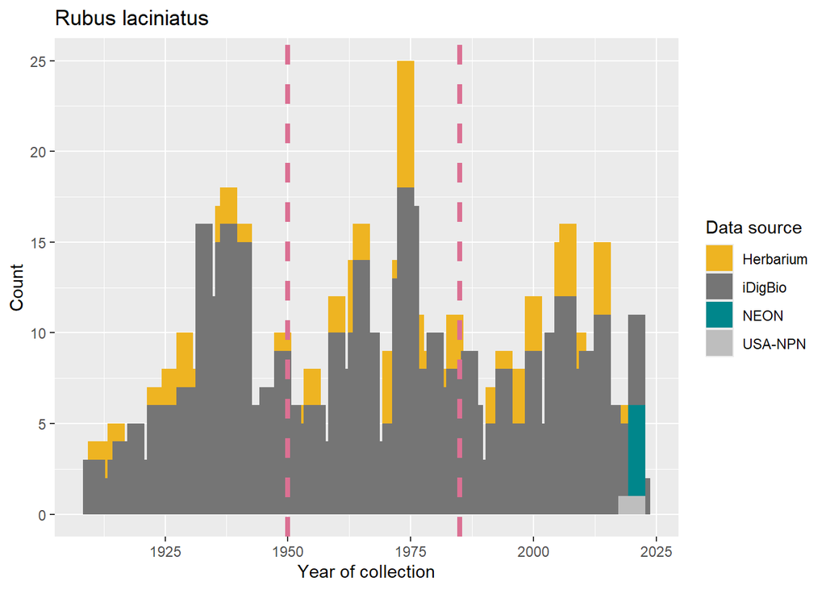

```r
stakd.hist("Rubus laciniatus")
```

## Maps

Let’s see the spatial spread of the observations. The NEON domain map shapefile use is from the [NEON web](https://www.neonscience.org/data-samples/data/spatial-data-maps). Also found in the Cyverse L1 data folder

```r
#import NEON domain maps - can be found on NEON website
domain.sh = st_read(file.path(domain, "NEON_Domains_CONUS.shp"))
#prepping for the function & mapping
#back up df
df = phe.n0
#remove rows with NAs in lat/long columns
df = df[!is.na(df$latitude), ]
df = df[!is.na(df$longitude), ]
#Convert the `phe.data` into a sf vector object ("point shapefile") for mapping
phe.sh = st_as_sf(df, coords = c("longitude", "latitude"), crs = st_crs(domain.sh)) #this function gets grumpy if lat/long columns have NAs
```

Let’s create a function to for the repetitive mapping.

```r
#Function to spatially map observations
#inputs: soi = species of interest, genus = genus info
#outputs: saved png image
#---------------------------------
mappin <- function(soi, genus){ #START of map function

  #if statement to automatically install libraries if absent in r library
  #tidyverse - mainly for data wrangling & plotting/mapping
  if (!requireNamespace("patchwork", quietly = TRUE)) {
    install.packages("patchwork")
  }
  library(patchwork) #for plot stacking at the end


  ##HISTORICAL
  #Making temp df name for historical
  df = phe.sh %>%
    #remove any inactive phenophase status (i.e. 0s) - want to be conservative and only view sample sizes for active flowering status
  #Also, only keep observations between 1910-1950
    filter(year_rect>=1910, year_rect <=1950,
         species == soi)
    ##Plotting - Historical
    #base later is domain map
    h <- ggplot(st_geometry(domain.sh)) +
      #aesthetics for base layer
      geom_sf(fill='grey95', color='grey30')+ #adjusting the polygon & line colors
      #Mapping next layer - points based on species (1 species)
      geom_sf(data = df, mapping = aes(color = species)) +
      #split into two maps for native status
      facet_wrap(~native_status) +
      #Manually change the color of the points
      scale_color_manual(values= c("dodgerblue", "darkgreen"))+ #order: non-native, native
      #Adjust the plot window / axes limits
      coord_sf(ylim = c(25, 50), xlim = c(-123, -69)) +
      #Axes labels
      labs(title = expression("Historical Observations"),
           x = "Longitude",
           y = "Latitude") +
      #theme voide removes everything but map
      theme_void() +
      #Adjust theme aesthetics
      theme(legend.position = "none",
            plot.title = element_text(size = 26, hjust=0.5)) #legend position, plot title font size & position


  ##CURRENT
  #Making temp df name for current
  df = phe.sh %>%
    #remove any inactive phenophase status (i.e. 0s) - want to be conservative and only view sample sizes for active flowering status
  #Also, only keep observations since 2009 (start of NEON/NPN)
    filter(year_rect>=1985, species == soi)
    ##Plotting - Current
    #base later is domain map
    c <- ggplot(st_geometry(domain.sh)) +
      #aesthetics for base layer
      geom_sf(fill='grey95', color='grey30')+ # #B9E0A5 (light green)
      #Mapping next layer - points based on species (1 species)
      geom_sf(data = df, mapping = aes(color = species)) +
      #split into two maps for native status
      facet_wrap(~native_status) +
      #Manually change the color of the points
      scale_color_manual(values= c("dodgerblue", "darkgreen"))+ #order: non-native, native
      # scale_shape_manual(values=c(16)) +
      # scale_size_manual(values= 10) +
      #Adjust the plot window / axes limits
      coord_sf(ylim = c(25, 50), xlim = c(-123, -69)) +
      #Axes labels
      labs(title = expression("Current Observations"),
           x = "Longitude",
           y = "Latitude") +
      #theme voide removes everything but map
      theme_void() +
      #Adjust theme aesthetics
      theme(legend.position = "none",
            plot.title = element_text(size = 26, hjust=0.5)) #legend position, plot title font size & position


  #using patchwork library to stack the two plots
  h/c


  #########
  # Exporting maps - uncomment and rerun function to save maps

  # Save the plot in the specified directory
  # ggsave(paste0("Map_", genus, "_pairs.png"),
  # last_plot(),
  # width = 7, units = "in", dpi = 600) #dpi the resolution
} #END of map function
```

Apply the function to each species pair. iDigBio data will be missing lots of geolocation info, as expected since they are unprocessed.

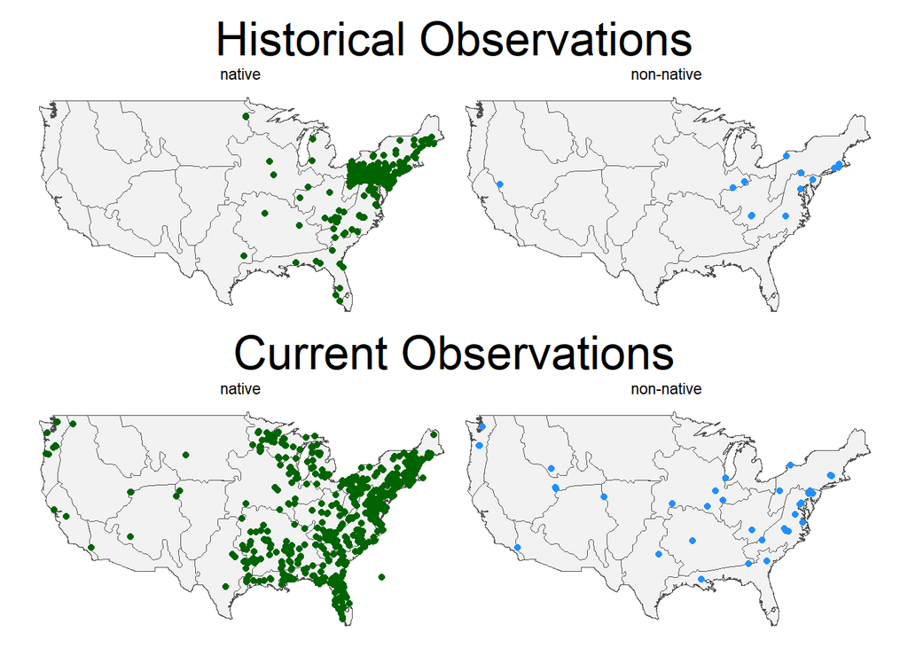

```r
#Acer spp
mappin(soi = c("Acer rubrum", "Acer palmatum"), genus = "Acer")
```

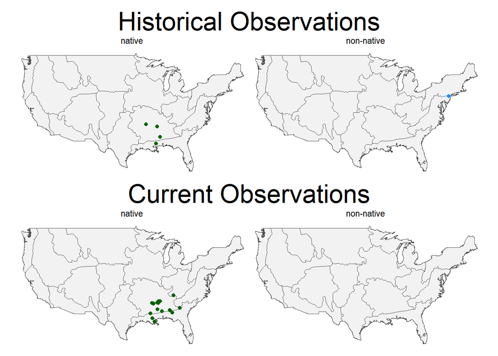

```r
#Hymenocallis spp
mappin(soi = c("Hymenocallis occidentalis", "Hymenocallis littoralis"), genus = "Hymenocallis")
```

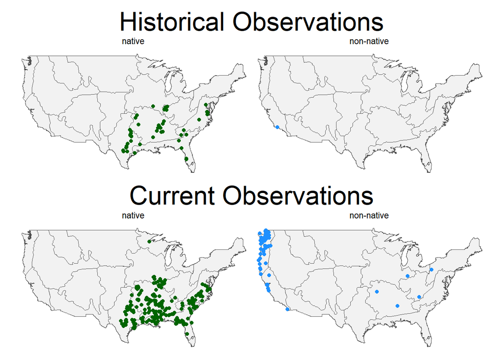

```r
#Ilex spp
mappin(soi = c("Ilex decidua", "Ilex aquifolium"), genus = "Ilex")
```

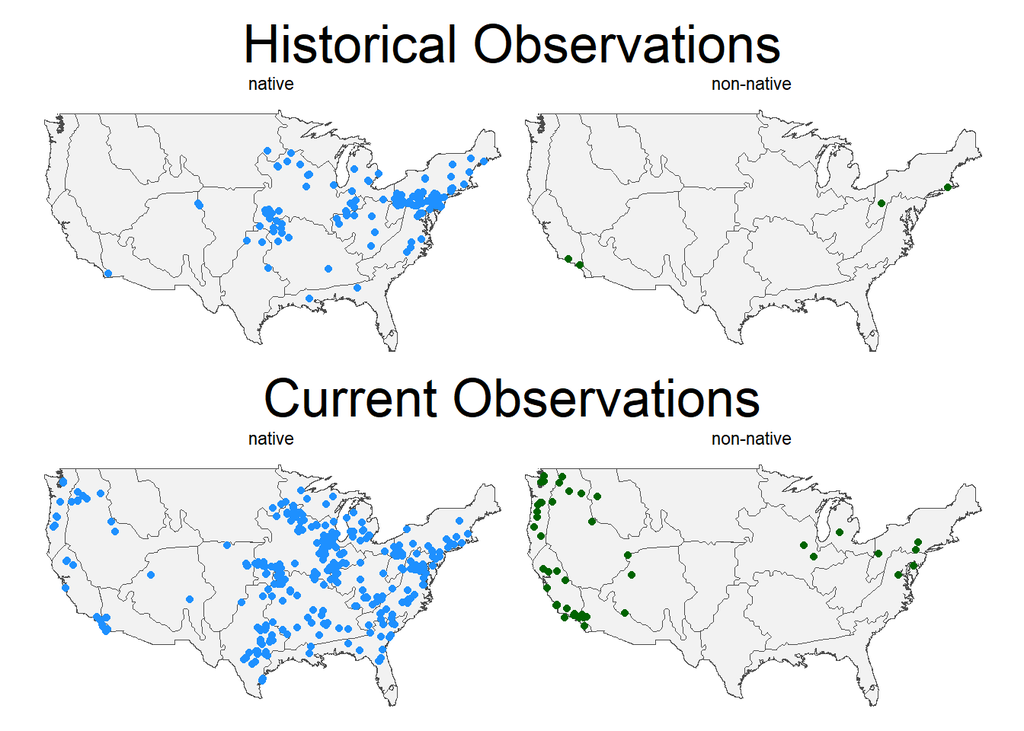

```r
#Juglans spp
mappin(soi = c("Juglans nigra", "Juglans regia"), genus = "Juglans")
```

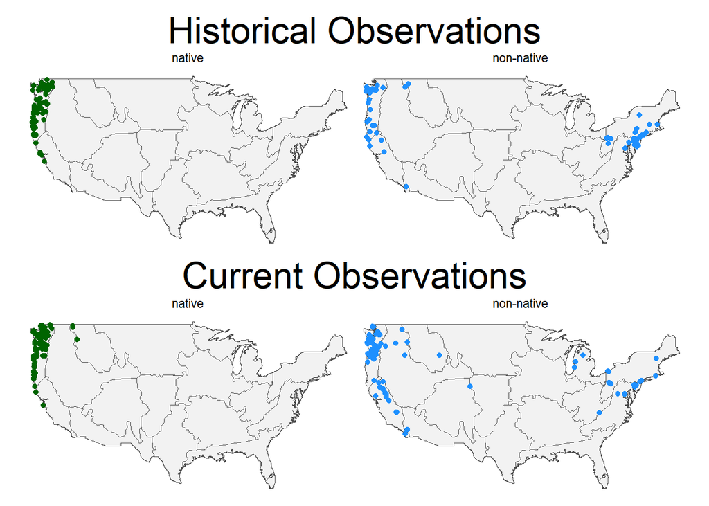

```r
#Rubus spp
mappin(soi = c("Rubus spectabilis", "Rubus laciniatus"), genus = "Rubus")
```